# capitulo 1

# CAPÍTULO 1

## Datos y estadística

- **1.1 APLICACIONES EN NEGOCIOS Y ECONOMIA**
- Contabilidad
- Finanzas
- Marketing
- Producción
- Economía
- **1.2 DATOS**
- Elementos, variables y observaciones
- Escalas de medición
- Datos categóricos y cuantitativos
- Datos de corte transversal y de series de tiempo
- **1.3 FUENTE DE DATOS**
- Fuentes existentes
- Estudios estadísticos
- Errores en la adquisición de datos
- **1.4 ESTADÍSTICA DESCRIPTIVA**
- **1.5 INFERENCIA ESTADISTICA**
- **1.6 COMPUTADORAS Y ANÁLISIS ESTADÍSTICO**
- **1.7 MINERÍA DE DATOS**
- **1.8 LINEAMIENTOS ÉTICOS PARA LA PRÁCTICA ESTADÍSTICA**

**Tabla 1.1** Rendimientos de varios fondos de inversión ofrecidos por Fortaleza SAFI en Bolivia

| Nombre del Fondo | Tipo de Moneda | Valor de la Cuota | Rendimiento T30d (%) | Rendimiento T360d (%) |
| --- | --- | --- | --- | --- |
| Fondo Disponible | Bolivianos (Bs) | 593.7393 | 2.50 | 2.53 |
| Fondo Inversión Internacional | Dólares (USD) | 1.0000 | 1.52 | 1.29 |
| Fondo Interés + | Bolivianos (Bs) | 1,744.8408 | 2.42 | 2.42 |
| Fondo UFV Rendimiento Total | UFV | 915.5883 | 2.47 | 2.61 |
| Fondo Liquidez | Dólares (USD) | 267.7532 | 0.72 | 1.06 |
| Fondo Produce Ganancia | Dólares (USD) | 182.9020 | 0.69 | 0.97 |
| Fondo Planifica | Bolivianos (Bs) | 419.2739 | 2.43 | 2.48 |
| Fondo Potencia Bolivianos | Bolivianos (Bs) | 6,495.4492 | 2.32 | 2.39 |
| Fondo Renta Mixta Internacional | Dólares (USD) | 131.7955 | 0.87 | 1.22 |
| Fondo Porvenir | Dólares (USD) | 203.8964 | 0.92 | 1.11 |

**Figura 1.1** Precio promedio por galón para la gasolina regular convencional en Estados Unidos

```python
import matplotlib.pyplot as plt
import pandas as pd

# Puntos de datos, asumiendo una frecuencia mensual desde Marzo 2006 hasta Julio 2009
fechas = pd.date_range(start="2006-03-01", periods=41, freq='M')
precios = [
    2.30, 2.25, 2.20, 2.20, 2.25, 2.35, 2.30, 2.35, 2.40, 2.45,
    2.50, 2.60, 2.55, 2.50, 2.55, 2.60, 2.65, 2.70, 2.75, 2.80,
    2.85, 3.00, 3.10, 3.25, 3.50, 3.60, 3.70, 3.80, 4.00, 4.10,
    4.20, 4.35, 4.00, 3.75, 3.50, 3.25, 3.00, 2.75, 2.50, 2.30,
    2.20
]

# Crear un DataFrame de los datos
datos = pd.DataFrame({'Fecha': fechas, 'Precio': precios})

# Configuración gráfica
plt.figure(figsize=(10, 5))
plt.plot(datos['Fecha'], datos['Precio'], marker='o', color='#009929')
plt.grid(True, which='both', linestyle='--', linewidth=0.5)
plt.title('Precio medio por galón')
plt.xlabel('Fecha')
plt.ylabel('Precio medio por galón')
plt.ylim(0, 4.5)
plt.xlim(datos['Fecha'].min(), datos['Fecha'].max())

# Color de fondo
ax = plt.gca()
ax.set_facecolor('#D4F8B7')  # Color de fondo
fig = plt.gcf()
fig.patch.set_facecolor('#D4F8B7')  # Color de fondo (figura)

# Mostrar la gráfica
plt.show()
```

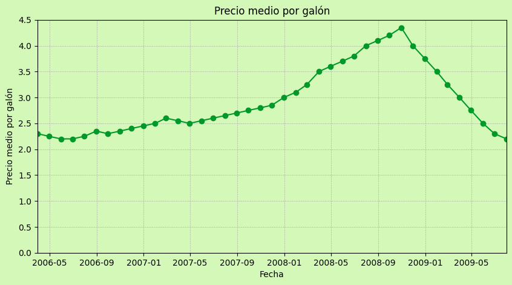

**Fuente.** Energy Information Administration, U.S. Department of Energy, mayo de 2009

**Figura 1.2** Varias Gráficas de series de tiempo

```python
import matplotlib.pyplot as plt
import pandas as pd

# Ajustamos las fechas para que coincidan con el número de valores proporcionados del Dow Jones
fechas = pd.date_range(start="1998-01-01", periods=15, freq='A-DEC')

# Valores aproximados del Promedio industrial Dow Jones extraídos del gráfico
valores_dow_jones = [
    8200,  9100, 10700, 9800,  8800,  9000, 10200, 10400, 11000,
    12400, 13000, 12800, 11800, 9000,  8500
]

# Crear un DataFrame con los datos ajustados
datos_dow_jones = pd.DataFrame({'Año': fechas, 'Promedio industrial Dow Jones': valores_dow_jones})

# Configuración de la gráfica
plt.figure(figsize=(10, 5))
plt.plot(datos_dow_jones['Año'], datos_dow_jones['Promedio industrial Dow Jones'], color='#009929')
plt.grid(True, which='both', linestyle='--', linewidth=0.5)
plt.title('(A) Promedio industrial Dow Jones')
plt.xlabel('Año', fontweight='bold')
plt.ylabel('Promedio industrial Dow Jones')
plt.ylim(5000, 14000)  # Establecer los límites del eje y
plt.xlim(datos_dow_jones['Año'].min(), datos_dow_jones['Año'].max())  # Establecer los límites del eje x

# Color de fondo
ax = plt.gca()
ax.set_facecolor('#D4F8B7')  # Color de fondo claro
fig = plt.gcf()
fig.patch.set_facecolor('#D4F8B7')  # Color de fondo para la figura

# Mostrar la gráfica
plt.show()
```

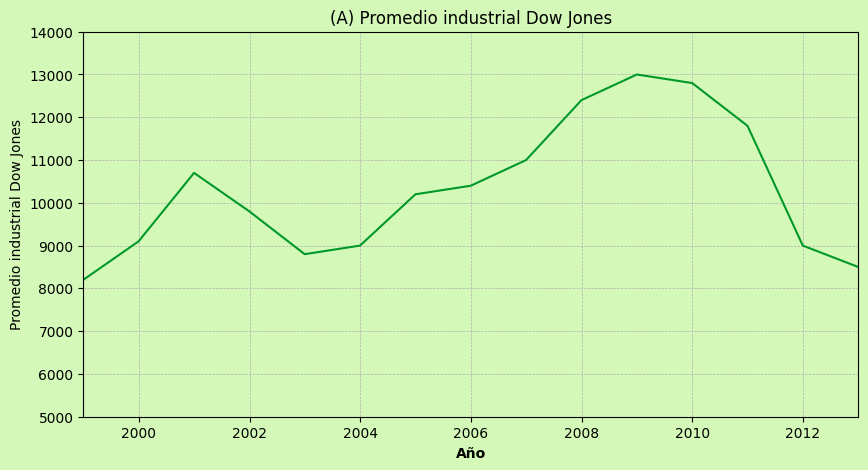

```python
import matplotlib.pyplot as plt
import pandas as pd

# Años representados en el gráfico
años = [2003, 2004, 2005, 2006, 2007, 2008, 2009]

# Valores aproximados de la utilidad neta de McDonald's (en millones de $) extraídos del gráfico
utilidades = [
    1.5, 2.0, 2.5, 2.0, 3.5, 4.0, 5.5
]

# Crear un DataFrame para los datos
datos_utilidad_mcdonalds = pd.DataFrame({'Año': años, 'Utilidad neta (millones $)': utilidades})

# Configuración del gráfico de barras con bordes negros
plt.figure(figsize=(8, 6))
plt.bar(datos_utilidad_mcdonalds['Año'],
        datos_utilidad_mcdonalds['Utilidad neta (millones $)'],
        color='#5CCB5F',
        edgecolor='black')  # Agregar borde negro a las barras
plt.title('(B) Utilidad neta de McDonald’s Inc.')
plt.xlabel('Año', fontweight='bold')
plt.ylabel('Utilidad neta (millones $)')
plt.ylim(0, 6)  # Establecer los límites del eje y

# Color de fondo
ax = plt.gca()
ax.set_facecolor('#D4F8B7')  # Color de fondo claro
fig = plt.gcf()
fig.patch.set_facecolor('#D4F8B7')  # Color de fondo para la figura

# Mostrar el gráfico de barras
plt.show()
```

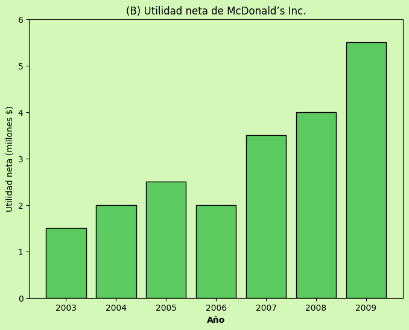

```python
import matplotlib.pyplot as plt
import pandas as pd

# Meses representados en el gráfico
meses = ['Ene', 'Feb', 'Mar', 'Abr', 'May', 'Jun', 'Jul', 'Ago', 'Sep', 'Oct', 'Nov', 'Dic']

# Valores aproximados de la tasa de ocupación de los hoteles del sur de Florida (en porcentaje)
tasas_ocupacion = [
    70, 80, 82, 75, 68, 65, 60, 55, 58, 62, 68, 75
]

# Crear un DataFrame para los datos
datos_ocupacion_hoteles = pd.DataFrame({'Mes': meses, 'Porcentaje de ocupación': tasas_ocupacion})

# Configuración del gráfico de barras
plt.figure(figsize=(10, 6))
plt.bar(datos_ocupacion_hoteles['Mes'], datos_ocupacion_hoteles['Porcentaje de ocupación'], color='#5CCB5F', edgecolor='black')
plt.title('(C) Tasa de ocupación de los hoteles del sur de Florida')
plt.xlabel('Mes', fontweight='bold')
plt.ylabel('Porcentaje de ocupación')
plt.ylim(0, 100)  # Establecer los límites del eje y

# Color de fondo
ax = plt.gca()
ax.set_facecolor('#D4F8B7')  # Color de fondo claro
fig = plt.gcf()
fig.patch.set_facecolor('#D4F8B7')  # Color de fondo para la figura

# Mostrar el gráfico de barras
plt.show()
```

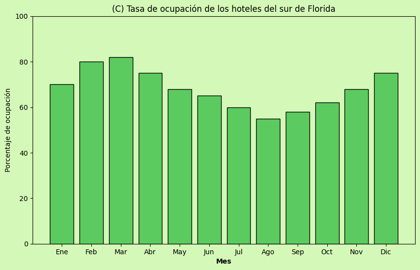

**Tabla 1.2** Ejemplos de datos disponibles de los registros internos de una empresa

| Fuente | Algunos datos comúnmente disponibles |
| --- | --- |
| Registros de empleados | Nombre, domicilio, número de Seguro Social, sueldo, número de días de vacaciones, número de días de incapacidad y bonos |
| Registros de producción | Número de parte o de producto, cantidad producida, costo de mano de obra directa y costo de los materiales |
| Registros de inventarios | Número de parte o de producto, cantidad de unidades disponible, punto de reorden, lote económico y programa de descuentos |
| Registros de ventas | Número de producto, volumen de ventas, volumen de ventas por región y volumen de ventas por tipo de cliente |
| Registros de crédito | Nombre del cliente, domicilio, número telefónico, límite de crédito y saldo de las cuentas por cobrar |
| Perfiles de clientes | Edad, género, nivel de ingresos, número de miembros en la familia, domicilio y preferencias |

**Tabla 1.3** Ejemplos de datos disponibles de algunas agencias gubernamentales

| Agencia gubernamental | Algunos datos disponibles |
| --- | --- |
| Oficina del Censo | Datos poblacionales, número de familias e ingresos por familia |
| Consejo de la Reserva Federal | Datos sobre la masa monetaria, crédito a plazo, tipos de cambio y tasas de descuento |
| Oficina de Administración y Presupuesto | Datos sobre ingresos, gastos y deudas del gobierno federal |
| Departamento de Comercio | Datos sobre la actividad comercial, valor de las remesas por industria, nivel de utilidades por industria e industrias en crecimiento y en declive |
| Oficina de Estadísticas Laborales | Gasto de los consumidores, ganancias por hora, tasa de desempleo, registros de seguridad y estadísticas internacionales |

**Figure 1.4** Cuestionario de opinión del cliente usado por el restaurante Chops City Grill en Naples, Florida